# Chapter 3: Logistic regression

(12.11.-18.11.2019)

- **Work through the DataCamp**

  DataCamp 4 Logistic regression
- **Data wrangling**

  R script of data Wrangling exercise is available here.

  https://github.com/yufanyin/IODS-project/blob/master/create_alc.R

  The result was saved as ‘alc.csv’.

**Note:** ‘(Step N)’ is used for reviewers to check my work queicky.

## 3.1 Reading the data

**Read the data file (Step 2a)**

```r
getwd()
```

```
## [1] "G:/C-Open Data Science/0-191030/IODS-project-master"
```

```r
setwd("G:/C-Open Data Science/0-191030/IODS-project-master")
alc <- read.csv(file = "G:/C-Open Data Science/0-191030/IODS-project-master/alc.csv")
```

**Print out the names of the variables in the data (Step 2b)**

```r
dim(alc)
```

```
## [1] 382  36
```

```r
colnames(alc)
```

```
##  [1] "X"          "school"     "sex"        "age"        "address"
##  [6] "famsize"    "Pstatus"    "Medu"       "Fedu"       "Mjob"
## [11] "Fjob"       "reason"     "nursery"    "internet"   "guardian"
## [16] "traveltime" "studytime"  "failures"   "schoolsup"  "famsup"
## [21] "paid"       "activities" "higher"     "romantic"   "famrel"
## [26] "freetime"   "goout"      "Dalc"       "Walc"       "health"
## [31] "absences"   "G1"         "G2"         "G3"         "alc_use"
## [36] "high_use"
```

```r
str(alc)
```

```
## 'data.frame':    382 obs. of  36 variables:
##  $ X         : int  1 2 3 4 5 6 7 8 9 10 ...
##  $ school    : Factor w/ 2 levels "GP","MS": 1 1 1 1 1 1 1 1 1 1 ...
##  $ sex       : Factor w/ 2 levels "F","M": 1 1 1 1 1 2 2 1 2 2 ...
##  $ age       : int  18 17 15 15 16 16 16 17 15 15 ...
##  $ address   : Factor w/ 2 levels "R","U": 2 2 2 2 2 2 2 2 2 2 ...
##  $ famsize   : Factor w/ 2 levels "GT3","LE3": 1 1 2 1 1 2 2 1 2 1 ...
##  $ Pstatus   : Factor w/ 2 levels "A","T": 1 2 2 2 2 2 2 1 1 2 ...
##  $ Medu      : int  4 1 1 4 3 4 2 4 3 3 ...
##  $ Fedu      : int  4 1 1 2 3 3 2 4 2 4 ...
##  $ Mjob      : Factor w/ 5 levels "at_home","health",..: 1 1 1 2 3 4 3 3 4 3 ...
##  $ Fjob      : Factor w/ 5 levels "at_home","health",..: 5 3 3 4 3 3 3 5 3 3 ...
##  $ reason    : Factor w/ 4 levels "course","home",..: 1 1 3 2 2 4 2 2 2 2 ...
##  $ nursery   : Factor w/ 2 levels "no","yes": 2 1 2 2 2 2 2 2 2 2 ...
##  $ internet  : Factor w/ 2 levels "no","yes": 1 2 2 2 1 2 2 1 2 2 ...
```

[output cut: 22 more lines]

**Describe the data set briefly (Step 2c)**

**Note:** It shows 36 variables. Why the first colname is “X” (int 1 2 3 4 5 6 7 8 9 10 …)?

The data were collected by using school reports and questionnaires from students in two Portugal secondary schools. They included students’ grades, demographic characteristics, social and school related features.

The two data sets provided students’ performance in Mathematics (mat) and Portuguese language (por). After data wrangling part, they were merged into one data set “alc”.

To analyse alcohol consumption, two new variables were created. “alc_use” is the average of weekday (“Dalc”) and weekend (“Walc”) alcohol consumption. “high_use” is the logical value created if the “alc_use” of a student is higher than 2 (TRUE).

Data source: https://archive.ics.uci.edu/ml/datasets/Student+Performance

## 3.2 Hypotheses about the relationships between alcohol consumption and specific variables

**Choose variables and write hypotheses (Step 3)**

The purpose of the following analysis is to explore the relationships between high/low alcohol consumption and some variables. I chose the following four variables:

‘sex’: student’s sex (binary: ‘F’ - female or ‘M’ - male)

‘failures’: number of past class failures (numeric: n if 1<=n<3, else 4)

‘goout’: going out with friends (numeric: from 1 - very low to 5 - very high)

‘absences’: number of school absences (numeric: from 0 to 93)

The hypotheses are as follows.

**Hypothesis 1:** There is gender difference (‘sex’) in alcohol consumption. In social science, gender affect many behaviors and preferences and becomes a variable being tested often.

**Hypothesis 2:** The number of class failures (‘failures’) associates with alcohol consumption. Students with more class failures have higher alcohol consumption.

**Hypothesis 3:** The frequency of going out with friends (‘goout’) associates with alcohol consumption. Students going out with friends more often have higher alcohol consumption.

**Hypothesis 4:** The number of school absences (‘absences’) associates with alcohol consumption. Students having more times of school absences have higher alcohol consumption.

## 3.3 Exploring the relationships numerically and graphically

**(Step 4)**

```r
library(tidyr)
library(dplyr)
library(ggplot2)
library(knitr)
library(kableExtra)
```

### 3.3.1 Alcohol consumption and gender

```r
alc %>% group_by(sex) %>% summarise(count = n()) -> fm
knitr::kable(fm, caption="Students' gender distribution") %>% kable_styling(bootstrap_options = "hover", full_width = FALSE, position = "center")
```

Students’ gender distribution

| sex | count |
| --- | --- |
| F | 198 |
| M | 184 |

There were 198 female students and 184 male students.

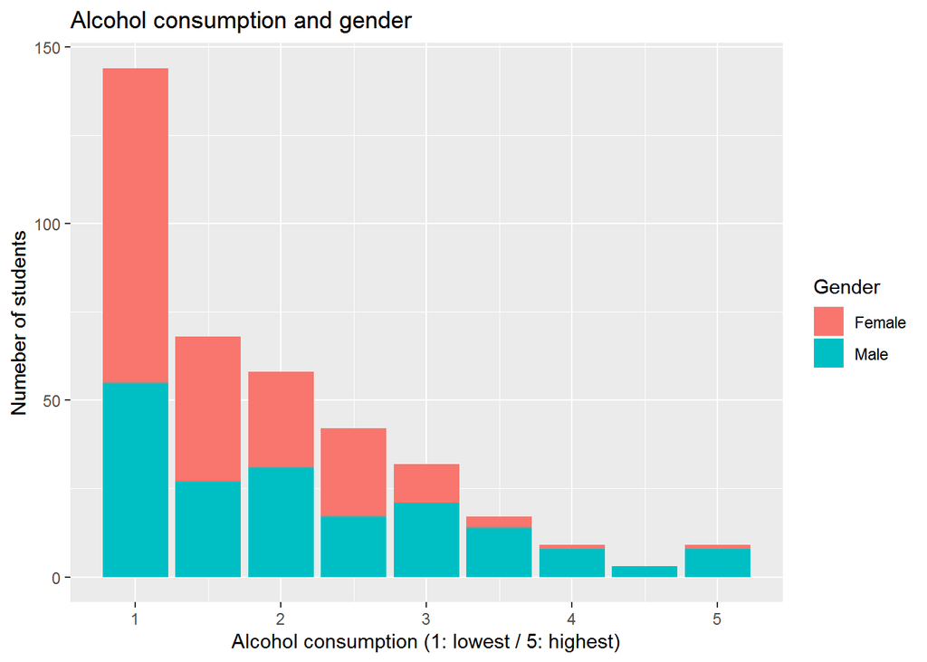

```r
ggplot(data = alc, aes(x = alc_use, fill = sex)) + geom_bar() + xlab("Alcohol consumption (1: lowest / 5: highest)") + ylab("Numeber of students") + ggtitle("Alcohol consumption and gender") + scale_fill_discrete("Gender", labels = c("Female", "Male"))
```

Te figure presents the distribution of alcohol consumption taking gender into account. 1 means the lowest consumption, 5 is the highest consumption.

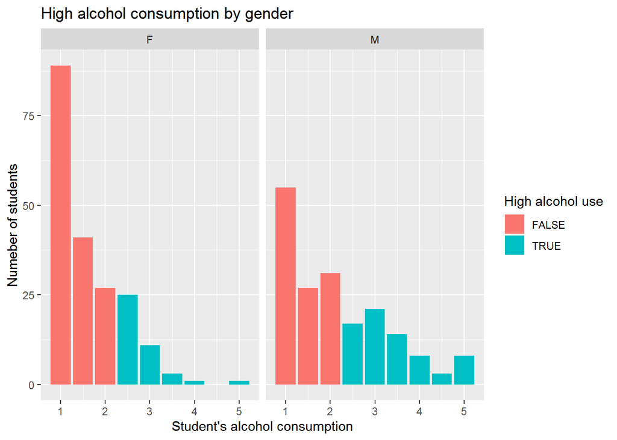

```r
ggplot(data = alc, aes(x = alc_use, fill = high_use)) + facet_wrap("sex") + geom_bar() + xlab("Student's alcohol consumption") + ggtitle("High alcohol consumption by gender") + ylab("Numeber of students") + scale_fill_discrete("High alcohol use")
```

### 3.3.2 Alcohol consumption and number of class failures

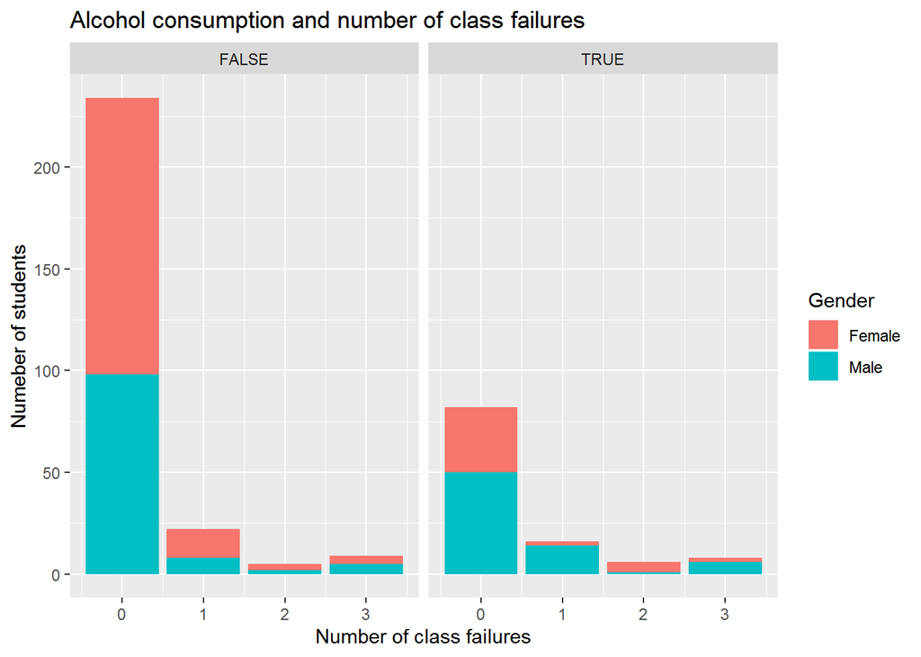

```r
ggplot(data = alc, aes(x = failures,  fill = sex)) + geom_bar() + facet_wrap("high_use") + ggtitle("Alcohol consumption and number of class failures") + xlab("Number of class failures") + ylab("Numeber of students") + scale_fill_discrete("Gender", labels = c("Female", "Male"))
```

### 3.3.3 Alcohol consumption and frequency of going out with friends

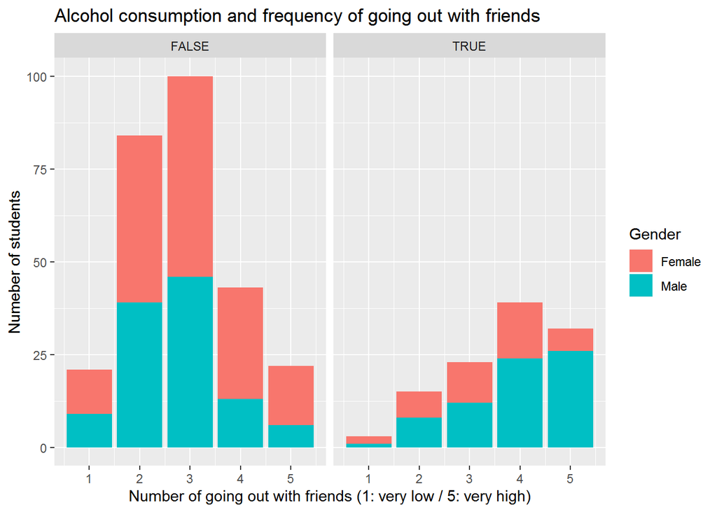

```r
ggplot(data = alc, aes(x = goout,  fill = sex)) + geom_bar() + facet_wrap("high_use") + ggtitle("Alcohol consumption and frequency of going out with friends") + xlab("Number of going out with friends (1: very low / 5: very high)") + ylab("Numeber of students") + scale_fill_discrete("Gender", labels = c("Female", "Male"))
```

### 3.3.4 Alcohol consumption and number of school absences

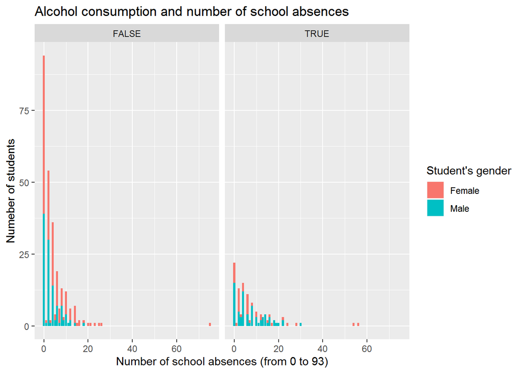

```r
ggplot(data = alc, aes(x = absences,  fill = sex)) + geom_bar() + facet_wrap("high_use") + ggtitle("Alcohol consumption and number of school absences") + xlab("Number of school absences (from 0 to 93)") + ylab("Numeber of students") + scale_fill_discrete("Student's gender", labels = c("Female", "Male"))
```

## 3.4 Exploring the relationship using logistic regression

### 3.4.1 The fitted model

**(Step 5a)**

‘sex’, ‘failures’,‘goout’ and ‘absences’

```r
lr_glm <- glm(high_use ~ sex + failures + goout + absences, data = alc, family = "binomial")
lr_glm_sum <- summary(lr_glm)
```

### 3.4.2 The coefficients of the model

**(Step 5b)**

```r
lr_glm_sum
```

```
##
## Call:
## glm(formula = high_use ~ sex + failures + goout + absences, family = "binomial",
##     data = alc)
##
## Deviance Residuals:
##     Min       1Q   Median       3Q      Max
## -1.8046  -0.7661  -0.5196   0.7383   2.3862
##
## Coefficients:
##             Estimate Std. Error z value Pr(>|z|)
## (Intercept) -4.21840    0.47865  -8.813  < 2e-16 ***
## sexM         0.97670    0.25898   3.771 0.000162 ***
## failures     0.28657    0.17170   1.669 0.095111 .
## goout        0.71559    0.12089   5.919 3.24e-09 ***
## absences     0.06550    0.01685   3.888 0.000101 ***
## ---
## Signif. codes:  0 '***' 0.001 '**' 0.01 '*' 0.05 '.' 0.1 ' ' 1
##
## (Dispersion parameter for binomial family taken to be 1)
##
##     Null deviance: 462.21  on 381  degrees of freedom
## Residual deviance: 378.67  on 377  degrees of freedom
## AIC: 388.67
##
## Number of Fisher Scoring iterations: 4
```

```r
knitr::kable(lr_glm_sum$coefficients, digits = 3, align = "l", justify = "left", caption="Model coefficients of choosen variables") %>% kable_styling(bootstrap_options = "striped", full_width = F, position = "center")
```

Model coefficients of choosen variables

|  | Estimate | Std. Error | z value | Pr(>\|z\|) |
| --- | --- | --- | --- | --- |
| (Intercept) | -4.218 | 0.479 | -8.813 | 0.000 |
| sexM | 0.977 | 0.259 | 3.771 | 0.000 |
| failures | 0.287 | 0.172 | 1.669 | 0.095 |
| goout | 0.716 | 0.121 | 5.919 | 0.000 |
| absences | 0.066 | 0.017 | 3.888 | 0.000 |

**The output shows**

- Being a male student instead of a female student significantly (p < 0.001) increased the probability of high alcohol consumption.
- Class failure had a positive effect on high consumption with a smaller probability (p = 0.095).
- The frenquency of going out with friends had a significant positive effect on high alcohol consumption (p < 0.001).
- School absences had a significant positive effect on high alcohol consumption (< 0.001).

### 3.4.3 The odds ratios and confidence intervals

**(Step 5c)**

Odds ratios

```r
or_lr <- coef(lr_glm) %>% exp
or_lr
```

```
## (Intercept)        sexM    failures       goout    absences
##  0.01472214  2.65567230  1.33184898  2.04538456  1.06769512
```

Confidence intervals

```r
ci_lr <- confint(lr_glm) %>% exp
ci_lr
```

```
##                   2.5 %     97.5 %
## (Intercept) 0.005520616 0.03620626
## sexM        1.608518976 4.45004345
## failures    0.949933462 1.86808335
## goout       1.623552039 2.61096941
## absences    1.035225148 1.10698949
```

Print out the odds ratios with their confidence intervals

```r
od_conf <- cbind(or_lr, ci_lr)
colnames(od_conf) <- c("odds ratios","2.5 %", "97.5 %")
knitr::kable(od_conf, digits = 3, align = "l",  caption="Odds ratios and confidental intervals") %>% kable_styling(bootstrap_options = "striped", full_width = F, position = "center")
```

Odds ratios and confidental intervals

|  | odds ratios | 2.5 % | 97.5 % |
| --- | --- | --- | --- |
| (Intercept) | 0.015 | 0.006 | 0.036 |
| sexM | 2.656 | 1.609 | 4.450 |
| failures | 1.332 | 0.950 | 1.868 |
| goout | 2.045 | 1.624 | 2.611 |
| absences | 1.068 | 1.035 | 1.107 |

## 3.5 The predictive power of you model

**(Step 6)**

```r
probs <- predict(lr_glm, type = "response")
alc <- mutate(alc, prob = probs)
alc <- mutate(alc, pred = prob > 0.5)
select(alc, age, failures, goout, absences, high_use, prob, pred) %>% tail(20)
```

```
##     age failures goout absences high_use       prob  pred
## 363  17        0     3        8    FALSE 0.17542917 FALSE
## 364  17        0     5       14    FALSE 0.56870202  TRUE
## 365  18        0     4        0    FALSE 0.20488145 FALSE
## 366  18        0     2        2    FALSE 0.06560625 FALSE
## 367  18        0     3        4     TRUE 0.14068205 FALSE
## 368  18        0     3        0    FALSE 0.11188342 FALSE
## 369  17        0     4       17     TRUE 0.43966501 FALSE
## 370  18        0     4        4     TRUE 0.47069539 FALSE
## 371  18        0     3        5    FALSE 0.31703390 FALSE
## 372  17        0     3        2    FALSE 0.27608939 FALSE
## 373  19        1     2        0    FALSE 0.17887835 FALSE
## 374  18        1     3       14     TRUE 0.52713626  TRUE
## 375  18        0     3        2    FALSE 0.12557744 FALSE
## 376  18        0     3        7    FALSE 0.16615452 FALSE
## 377  19        1     2        0    FALSE 0.07581170 FALSE
## 378  18        0     4        0    FALSE 0.20488145 FALSE
## 379  18        1     1        0    FALSE 0.03855880 FALSE
## 380  18        1     1        0    FALSE 0.03855880 FALSE
## 381  17        0     5        3     TRUE 0.63011977  TRUE
## 382  18        0     1        0     TRUE 0.07404728 FALSE
```

```r
pred22 <- table(high_use = alc$high_use, pred = alc$pred)
knitr::kable(pred22, align = "l",  caption="2 x 2 cross tabulation" ) %>% kable_styling(bootstrap_options = "striped", full_width = F, position = "center") %>% add_header_above(c(" " = 1, "Pred" = 2)) %>%  pack_rows("High use", 1, 2)
```

2 x 2 cross tabulation

|  | Pred FALSE | Pred TRUE |
| --- | --- | --- |
| **High use** |  |  |
| FALSE | 251 | 19 |
| TRUE | 62 | 50 |

The model reported 251 correct false results and 62 false negative results. Among the 62 cases, students had high alcohol consumption but the model predicted not. Among the 19 false positive prediction cases, the model predicted high alcohol consumption but it was not in fact.

```r
loss_func <- function(class, prob) {
  n_wrong <- abs(class - prob) > 0.5
  mean(n_wrong)
}
loss_func(class = alc$high_use, prob = alc$prob)
```

```
## [1] 0.2120419
```

It showed that 21.2% of all predictions was incorrect.

## 3.6 The 10-fold cross-validation on the model

**(Step 7)**

```r
library(boot)
cross_val<- cv.glm(data = alc, cost = loss_func, glmfit = lr_glm, K = 10)
cross_val$delta[1]
```

```
## [1] 0.2120419
```

## 3.7 cross-validation to compare the performance of different logistic regression models

**(Step 8)**